# Significance Tests (Takasugi et al.)

Kimberly Truong

11/1/2021

### Dataset

This is the underlying data for Fig 4D. We aim to conduct the appropriate statistical test to support the following conclusions:

1. LbaCas12a creates more edits than SauCas9 and SpyCas9.
2. Our orthogonal Cas (hybrid) system generates significantly more edits than previous GESTALT systems.

To do this, we created a dataframe summarizing the average number of edits per barcode in each sample.

```r
numEdits.df <- read.table('data/numEditsperBarcode_byCRISPRSystem.tsv', header=TRUE, sep='\t', row.names='X')
head(numEdits.df, 20)
```

```
##    sample_id condition numEditsperBarcode_wt
## 0   Control1   Control            0.04441506
## 1   Control2   Control            0.02923240
## 2   Control3   Control            0.03272064
## 3   Control4   Control            0.02979679
## 4   Control5   Control            0.05085185
## 5   Control6   Control            0.03201238
## 6   Control7   Control            0.05659008
## 7   Control8   Control            0.03827603
## 8   Control9   Control            0.04659658
## 9  Control10   Control            0.03242956
## 10 Control11   Control            0.03048143
## 11 Control12   Control            0.03010805
## 12 Control13   Control            0.02952525
## 13 Control14   Control            0.03117374
## 14      Lba1       Lba            3.46889806
## 15      Lba2       Lba            1.86652603
## 16      Lba3       Lba            1.58631209
## 17      Lba4       Lba            2.56356723
## 18      Lba5       Lba            2.51122039
## 19      Lba6       Lba            3.13605028
```

### Normality Test for Single Systems

We first check for normality. Small sample sizes for single-edited systems make it hard to check confidently:

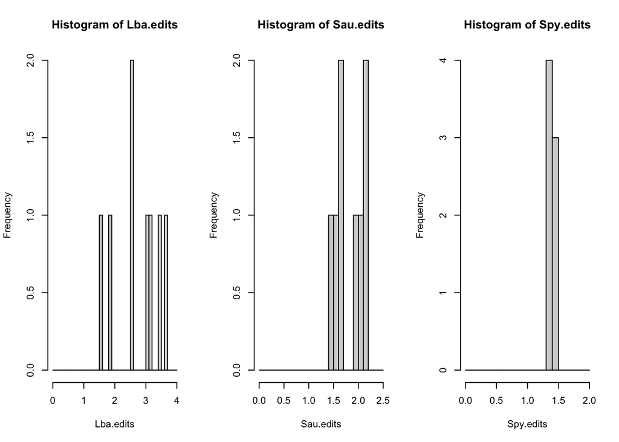

```r
Lba.edits <- numEdits.df[which(numEdits.df$condition=='Lba'),]$numEditsperBarcode_wt
Sau.edits <- numEdits.df[which(numEdits.df$condition=='Sau'),]$numEditsperBarcode_wt
Spy.edits <- numEdits.df[which(numEdits.df$condition=='Spy'),]$numEditsperBarcode_wt

par(mfrow=c(1,3))
hist(Lba.edits, breaks=seq(0,4,0.1))
hist(Sau.edits, breaks=seq(0,2.5,0.1))
hist(Spy.edits, breaks=seq(0,2,0.1))
```

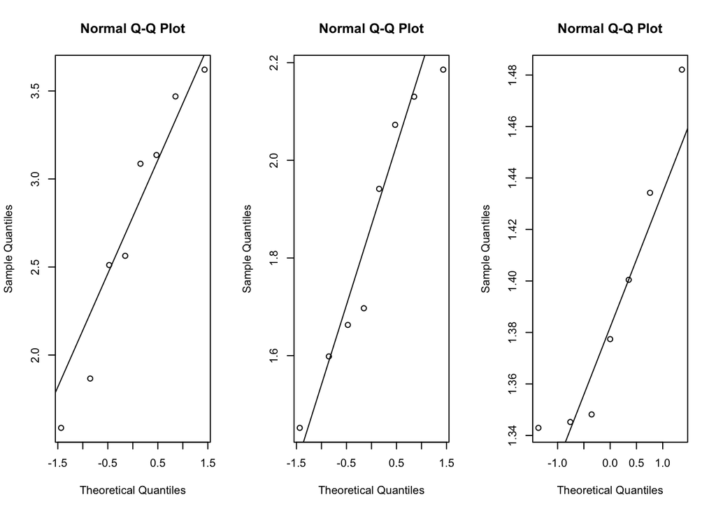

```r
par(mfrow=c(1,3))
qqnorm(sort(Lba.edits))
qqline(sort(Lba.edits))

qqnorm(sort(Sau.edits))
qqline(sort(Sau.edits))

qqnorm(sort(Spy.edits))
qqline(sort(Spy.edits))
```

Based on these QQ plots, it appears that our observed data are correlated with what we would expect if they were generated by a normal distribution. It’s not perfect, of course, but it doesn’t look like a bad approximation either. We can further confirm this with the Shapiro-Wilk normality test as it measures the correlation between the data and z-scores from a normal distribution.

### The Shapiro-Wilk Normality Test

```r
shapiro.test(Lba.edits)
```

```
##
##  Shapiro-Wilk normality test
##
## data:  Lba.edits
## W = 0.93663, p-value = 0.5783
```

```r
shapiro.test(Sau.edits)
```

```
##
##  Shapiro-Wilk normality test
##
## data:  Sau.edits
## W = 0.92047, p-value = 0.4337
```

```r
shapiro.test(Spy.edits)
```

```
##
##  Shapiro-Wilk normality test
##
## data:  Spy.edits
## W = 0.87885, p-value = 0.2214
```

As expected, small sample sizes have little power in rejecting the null hypothesis of normality. We can assume normality.

### Unpaired one-tailed t-test for Single Systems

```r
t.test(Lba.edits, Sau.edits, paired=FALSE, var.equal=FALSE, alternative='greater')
```

```
##
##  Welch Two Sample t-test
##
## data:  Lba.edits and Sau.edits
## t = 3.2064, df = 8.9299, p-value = 0.005415
## alternative hypothesis: true difference in means is greater than 0
## 95 percent confidence interval:
##  0.3796253       Inf
## sample estimates:
## mean of x mean of y
##  2.730033  1.842593
```

```r
t.test(Lba.edits, Spy.edits, paired=FALSE, var.equal=FALSE, alternative='greater')
```

```
##
##  Welch Two Sample t-test
##
## data:  Lba.edits and Spy.edits
## t = 5.1552, df = 7.0827, p-value = 0.0006348
## alternative hypothesis: true difference in means is greater than 0
## 95 percent confidence interval:
##  0.8483801       Inf
## sample estimates:
## mean of x mean of y
##  2.730033  1.390070
```

This supports our first claim of **Lba generating significantly more edits than Sau and Spy.**

### Normality Test for Hybrid/GESTALT systems

```r
library(dplyr)
hybrid.edits <- numEdits.df %>%
  filter(condition=="ALL") %>%
  select(numEditsperBarcode_wt)

scgestalt.edits <- numEdits.df %>%
  filter(condition=="scGESTALT") %>%
  select(numEditsperBarcode_wt)

gestalt.edits <- numEdits.df %>%
  filter(condition=="GESTALT") %>%
  select(numEditsperBarcode_wt)

shapiro.test(hybrid.edits$numEditsperBarcode_wt)
```

```
##
##  Shapiro-Wilk normality test
##
## data:  hybrid.edits$numEditsperBarcode_wt
## W = 0.96564, p-value = 0.335
```

```r
shapiro.test(scgestalt.edits$numEditsperBarcode_wt)
```

```
##
##  Shapiro-Wilk normality test
##
## data:  scgestalt.edits$numEditsperBarcode_wt
## W = 0.94238, p-value = 0.6346
```

```r
shapiro.test(gestalt.edits$numEditsperBarcode_wt)
```

```
##
##  Shapiro-Wilk normality test
##
## data:  gestalt.edits$numEditsperBarcode_wt
## W = 0.95571, p-value = 0.06774
```

We assume normality under significance level $\alpha = 0.05$.

### Unpaired one-tailed t-test for Hybrid vs. GESTALT systems

```r
t.test(hybrid.edits$numEditsperBarcode_wt, scgestalt.edits$numEditsperBarcode_wt, paired=FALSE, var.equal=FALSE, alternative='greater')
```

```
##
##  Welch Two Sample t-test
##
## data:  hybrid.edits$numEditsperBarcode_wt and scgestalt.edits$numEditsperBarcode_wt
## t = 7.3041, df = 31.38, p-value = 1.492e-08
## alternative hypothesis: true difference in means is greater than 0
## 95 percent confidence interval:
##  1.08984     Inf
## sample estimates:
## mean of x mean of y
##  4.972362  3.553218
```

```r
t.test(hybrid.edits$numEditsperBarcode_wt, gestalt.edits$numEditsperBarcode_wt, paired=FALSE, var.equal=FALSE, alternative='greater')
```

```
##
##  Welch Two Sample t-test
##
## data:  hybrid.edits$numEditsperBarcode_wt and gestalt.edits$numEditsperBarcode_wt
## t = 10.87, df = 73.333, p-value < 2.2e-16
## alternative hypothesis: true difference in means is greater than 0
## 95 percent confidence interval:
##  1.851361      Inf
## sample estimates:
## mean of x mean of y
##  4.972362  2.785908
```

We find that **our new hybrid CRISPR-Cas system produces significantly more edits, on average, than previously published GESTALT systems.**

### Analysis of Single-Site Edits

In our exploration, we computed the mean percentage of indels under each single CRISPR system. This ended up being the underlying data for Fig 4F.

```r
singleSiteEdits.df <- read.table('./data/indelRate_byCRISPRsystem.tsv', header=TRUE, sep='\t', row.names='X')
head(singleSiteEdits.df, 10)
```

```
##   sample_id condition percentIndels
## 0      Lba1       Lba     0.8464101
## 1      Lba2       Lba     0.8934017
## 2      Lba3       Lba     0.8949433
## 3      Lba4       Lba     0.8216193
## 4      Lba5       Lba     0.5848501
## 5      Lba6       Lba     0.6080746
## 6      Lba7       Lba     0.7381193
## 7      Lba8       Lba     0.7576646
## 8      Sau1       Sau     0.5630320
## 9      Sau2       Sau     0.7017982
```

```r
Lba.indels <- singleSiteEdits.df[which(singleSiteEdits.df$condition=='Lba'), 'percentIndels']
Sau.indels <- singleSiteEdits.df[which(singleSiteEdits.df$condition=='Sau'), 'percentIndels']
Spy.indels <- singleSiteEdits.df[which(singleSiteEdits.df$condition=='Spy'), 'percentIndels']

shapiro.test(Lba.indels)
```

```
##
##  Shapiro-Wilk normality test
##
## data:  Lba.indels
## W = 0.89392, p-value = 0.2544
```

```r
shapiro.test(Sau.indels)
```

```
##
##  Shapiro-Wilk normality test
##
## data:  Sau.indels
## W = 0.87017, p-value = 0.1513
```

```r
shapiro.test(Spy.indels)
```

```
##
##  Shapiro-Wilk normality test
##
## data:  Spy.indels
## W = 0.99551, p-value = 0.9993
```

We assume normality based on the results of the Shapiro-Wilk normality test.

### Unpaired one-tailed t-test for Single-Site Edits

```r
t.test(Lba.indels, Sau.indels, paired=FALSE, var.equal=FALSE, alternative='greater')
```

```
##
##  Welch Two Sample t-test
##
## data:  Lba.indels and Sau.indels
## t = 2.5202, df = 13.942, p-value = 0.01227
## alternative hypothesis: true difference in means is greater than 0
## 95 percent confidence interval:
##  0.04709081        Inf
## sample estimates:
## mean of x mean of y
## 0.7681354 0.6116512
```

```r
t.test(Lba.indels, Spy.indels, paired=FALSE, var.equal=FALSE, alternative='greater')
```

```
##
##  Welch Two Sample t-test
##
## data:  Lba.indels and Spy.indels
## t = 11.866, df = 8.4533, p-value = 7.319e-07
## alternative hypothesis: true difference in means is greater than 0
## 95 percent confidence interval:
##  0.4474843       Inf
## sample estimates:
## mean of x mean of y
## 0.7681354 0.2381754
```

We find that **LbaCas12a significantly generates more single-site edits than either SauCas9 or SpyCas9.**